# **HFD Microbiome: 16S Amplicon Pre-processing of 02-week Experiment**

Raw sequence processing and OTU table generation using usearch v11, OTU table cleaning using phyloseq (R), and basic data overview

Kelli Feeser

2025-02-04

**16S Primers:**  
- *341F* – 5′-CCT ACG GGN GGC WGC AG-3′  
- *805R* – 5′-GAC TAC HVG GGT ATC TAA TCC-3′

**Expected Insert Length:**  
- 465 bp

# 1 Basic Sequence Data Prep

## 1.1 Fastq file name formatting

**Raw Fastqs** are in folder *0_RawFastqs/RawFastqs_nameformatted*

- Names are formatted so that the identifying sample label appears before the first underscore. This makes the downstream auto fasta header relabeling seemless and ensures that when the sequences across samples are combined into 1 file, each sequence is properly labeled in the headers.
- For this project, sample ids were numeric values [427,516], so again for simplifying downstream processing, I renamed each raw fastqs file to have the prefix ‘hfd02wk’ and set all numberic values to have 3 digits.
  - Having only numberic values as sample identifiers is likely to create issues when reading into R/phyloseq
  - Naming examples:
    - “427” → “hfd02wk427”; files = 802_427-SetA_N701-S502__TAAGGCGA-CTCTCTAT__S268_R1_001.fastq → hfd02wk427_R1.fastq
    - “516” → “hfd02wk516”; files = 802_516-SetA_N715-S503__ATCTCAGG-TATCCTCT__S357_R1_001.fastq → hfd02wk516_R1.fastq

# Read-in raw USEARCH OTU tables, taxonomy, and metadata —-

## read-in raw 16S data

### 16S otu table

### 16S sintax taxonomy file

16S ref db: RDP 16S v19

### 16S metadata file

## 1.2 initiate phyloseq objects —–

# 2 basic data overview ———————————————————–

phyloseq-class experiment-level object otu_table() OTU Table: [ 4818 taxa and 90 samples ] sample_data() Sample Data: [ 90 samples by 18 sample variables ] tax_table() Taxonomy Table: [ 4818 taxa by 7 taxonomic ranks ]

- N samples: 90
- N OTUs: 4,818

**USEARCH version**  
usearch11.0.667_i86linux64

**Ref db: rdp_16s_v19**

- 24,642 sequences in taxonomic reference database

## 2.1 Full Datasets, unrarefied, unprunned

### 2.1.1 Read Counts

Table 2.1:

| Seqs per sample | Full 16S OTU table |
| --- | --- |
| min | 747 |
| max | 143,238 |
| mean | 89,796 |
| sd | 25,251 |
| total | 8,081,671 |

### 2.1.2 Unique Domains detected

#### 16S

```
## [1] "Bacteria"    "uncl_Domain" "Eukaryota"   "Archaea"
```

### 2.1.3 Reads per Domain

#### 02-week

Table 2.2:

| Domain | reads_assigned | percentage_all_reads |
| --- | --- | --- |
| Bacteria | 8,075,422 | 99.92% |
| uncl_Domain | 776 | 0.01% |
| Eukaryota | 5,469 | 0.07% |
| Archaea | 4 | 0.00% |

*For now, only continuing with reads assigned at >= 80% confidence to domain = Bacteria or Archaea*

# 3 Clean OTU table

## 3.1 Prune taxa

**Domain-level:**

**Phylum-level:**

3. Remove Phylum = “uncl_Bacteria” (77,821 reads; 3,529 OTUs)
4. Remove Phylum = “uncl_Archaea” (0 reads; 0 OTUs)
5. Look at Phylum “Cyanobacteriota”
   - It contains these Classes: Chloroplast

**Class-level:**

6. Remove Class = “Chloroplast” (1,491 reads; 2 OTUs)
7. Remove Class = “uncl_Cyanobacteria/Chloroplast” (0 reads; 0 OTUs)

**Family-level:**

8. Remove Family = “Mitochondria” (0 reads; 0 OTUs)

**Remaining data:**  
- 7,996,114 total reads  
- 88,845.71 average reads/sample  
- 734 OTUs  
- 90 samples

## 3.2 Removing singleton OTUs

At this point, the unrarefied **02wk** 16S dataset with unwanted taxa prunned has 734 OTUs and a total of 7,996,114 reads.

## 3.3 **02wk**

6 singleton OTUs were present and removed (corresponding to 6 reads)

- 728 OTUs remain
- 7,996,108 total reads remain
  - average: 88,845.64
  - sd: 25,618.79

## 3.4 BacArch OTU Rarefaction Curves

### 3.4.2 All samples, full depth range

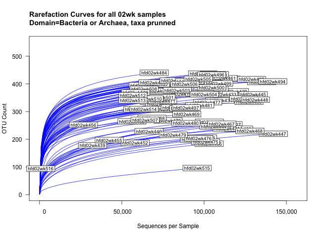

```r
par(mar = c(5.1, 4.1, 5.1, 2.1)) # c(bottom, left, top, right)

dev.copy(png,'/Users/L347123/Desktop/hfd-microbiome/docs/figures/rarefaction/Rarecurve_02wk_fullrange.png',width = 650)

plot_rarecurves((phylo2vegan_OTU(hfd_02wk_unrare_min2)), step = 1000,xlim=c(0,max(sample_sums(hfd_02wk_unrare_min2)*1.1)),ylim=c(0,550),
  title(main="Rarefaction Curves for all 02wk samples\nDomain=Bacteria or Archaea, taxa prunned", adj=0),
   label=T,cex.main=1.2)

dev.off()
```

### 3.4.3 All samples, max 35k seqs/samples

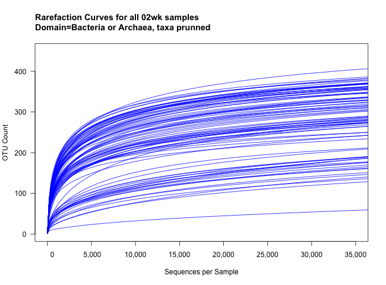

### 3.4.4 All samples, max 30k seqs/samples

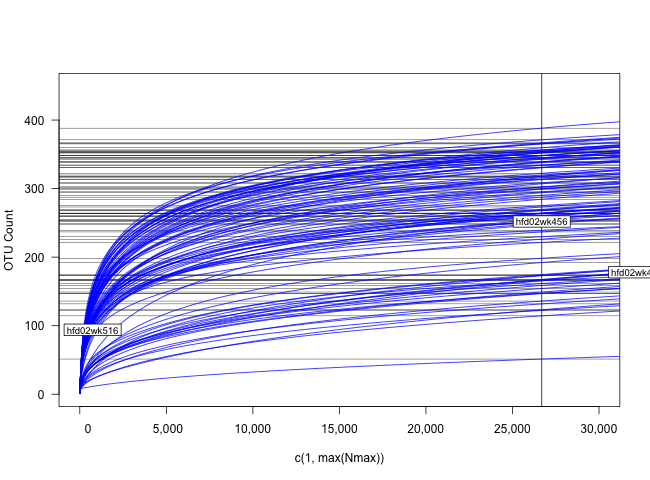

## 3.5 Rarefying 02wk OTU table to 26,694 seqs/sample

**Rarefaction threshold of 26,694 sequences per sample -> we’d lose:**

- 1 samples overall (1.1% of the total 90 samples)  
  – 21 OTUs (2.9% of the total 728 OTUs)  
  – 707 OTUs remain

*Of note, I am rarefying via subsampling WITHOUT replacement and removing OTUs no longer in dataset*

Indeed:  
- 1 samples removed because they contained fewer reads than `sample.size`.  
- 21 OTUs were removed because they are no longer present in any sample after random subsampling

# 4 Final OTU table stats

- 707 OTUs remain
- 2,375,766 total reads remain
  - average: 26,694
  - sd: 0